# Pertemuan 3_Model Regresi dengan Peubah Lag

Syifa Khairunnisa

2023-09-17

# Packages

```r
library(dLagM)
library(dynlm)
library(MLmetrics)
library(lmtest)
library(car)
```

# Data

Data yang saya gunakan berasal dari link: https://www.kaggle.com/datasets/anuragbantu/new-delhi-air-quality Peubah yang saya gunakan adalah AQI sebagai peubah respon (Yt) dan NO2 sebagai peubah penjelas (Xt)

```r
library(rio)
data <- import("https://raw.githubusercontent.com/syifaskn/MPDWPraktikum/main/Pertemuan%203/AQI_NewDelhi_NO2.csv")
data
```

```
##     t   Yt Ytmin1         Xt
## 1   1 30.2     NA 0.04685717
## 2   2 28.2   30.2 0.04645554
## 3   3 26.6   28.2 0.04685717
## 4   4 25.0   26.6 0.04819594
## 5   5 26.0   25.0 0.04886533
## 6   6 26.0   26.0 0.05020411
## 7   7 26.0   26.0 0.05020411
## 8   8 24.0   26.0 0.05020411
## 9   9 23.0   24.0 0.04685717
## 10 10 24.0   23.0 0.04417961
## 11 11 25.0   24.0 0.04284084
## 12 12 26.0   25.0 0.04049798
## 13 13 27.0   26.0 0.04016329
## 14 14 29.0   27.0 0.03882451
```

[output cut: 58 more lines]

```r
View(data)
```

# Data traning dan testing

```r
train<-data[1:58,]
test<-data[59:72,]
```

# Data time series

```r
train.ts<-ts(train)
test.ts<-ts(test)
data.ts<-ts(data)
```

## Model Koyck

Model Koyck didasarkan pada asumsi bahwa semakin jauh jarak lag peubah independen dari periode sekarang maka semakin kecil pengaruh peubah lag terhadap peubah dependen.

Fungsi `koyckDlm()` akan menerapkan model lag terdistribusi dengan transformasi Koyck satu prediktor. Nilai `x` dan `y` tidak perlu sebagai objek *time series* (`ts`). `intercept` dapat dibuat `TRUE` untuk memasukkan intersep ke dalam model.

```r
model.koyck <- koyckDlm(x = train$Xt, y = train$Yt)
summary(model.koyck)
```

```
##
## Call:
## "Y ~ (Intercept) + Y.1 + X.t"
##
## Residuals:
##      Min       1Q   Median       3Q      Max
## -2.14846 -0.54834 -0.04671  0.55341  2.25964
##
## Coefficients:
##             Estimate Std. Error t value Pr(>|t|)
## (Intercept)  1.99147    1.58621   1.255    0.215
## Y.1          0.88020    0.06305  13.960   <2e-16 ***
## X.t         25.33442   18.07104   1.402    0.167
## ---
## Signif. codes:  0 '***' 0.001 '**' 0.01 '*' 0.05 '.' 0.1 ' ' 1
##
## Residual standard error: 0.936 on 54 degrees of freedom
## Multiple R-Squared: 0.8243,  Adjusted R-squared: 0.8178
## Wald test: 125.9 on 2 and 54 DF,  p-value: < 2.2e-16
##
## Diagnostic tests:
## NULL
##
##                             alpha     beta       phi
## Geometric coefficients:  16.62273 25.33442 0.8801961
```

```r
AIC(model.koyck)
```

```
## [1] 159.136
```

```r
BIC(model.koyck)
```

```
## [1] 167.3082
```

Berikut adalah hasil peramalan y untuk 14 periode kedepan menggunakan model koyck

```r
fore.koyck <- forecast(model = model.koyck, x=test$Xt, h=14)
fore.koyck
```

```
## $forecasts
##  [1] 22.93128 22.71392 22.42934 22.13221 21.86644 21.69610 21.64792 21.69879
##  [9] 21.86227 22.13336 22.46524 22.88455 23.32146 23.72298
##
## $call
## forecast.koyckDlm(model = model.koyck, x = test$Xt, h = 14)
##
## attr(,"class")
## [1] "forecast.koyckDlm" "dLagM"
```

```r
mape.koyck <- MAPE(fore.koyck$forecasts, test$Yt)
#akurasi data training
GoF(model.koyck)
```

```
##              n       MAE          MPE       MAPE    sMAPE     MASE       MSE
## model.koyck 57 0.7025115 -0.001149676 0.02619192 0.026114 1.057544 0.8299675
##                  MRAE    GMRAE
## model.koyck 975249991 11827.09
```

# Regression with Distributed Lag

Fungsi `dlm()` akan menerapkan model lag terdistribusi dengan satu atau lebih prediktor. Nilai `x` dan `y` tidak perlu sebagai objek *time series* (`ts`). $q$ adalah integer yang mewakili panjang *lag* yang terbatas.

```r
#Pemodelan (Lag=2)
model.dlm <- dlm(x = train$Xt,y = train$Yt , q = 2)
summary(model.dlm)
```

```
##
## Call:
## lm(formula = model.formula, data = design)
##
## Residuals:
##     Min      1Q  Median      3Q     Max
## -4.1732 -1.3324 -0.2241  0.8610  3.9745
##
## Coefficients:
##             Estimate Std. Error t value Pr(>|t|)
## (Intercept)   20.172      1.652  12.207   <2e-16 ***
## x.t          203.517    111.604   1.824   0.0740 .
## x.1         -291.196    198.583  -1.466   0.1486
## x.2          240.707    117.925   2.041   0.0463 *
## ---
## Signif. codes:  0 '***' 0.001 '**' 0.01 '*' 0.05 '.' 0.1 ' ' 1
##
## Residual standard error: 1.957 on 52 degrees of freedom
## Multiple R-squared:  0.2564, Adjusted R-squared:  0.2135
## F-statistic: 5.976 on 3 and 52 DF,  p-value: 0.001405
##
## AIC and BIC values for the model:
##        AIC     BIC
## 1 239.9943 250.121
```

```r
AIC(model.dlm)
```

```
## [1] 239.9943
```

```r
BIC(model.dlm)
```

```
## [1] 250.121
```

$$\hat{Y_t}=20.172+203.517X_t-291.196X_{t-1}+240.707X_{t-2}$$
Berikut merupakan hasil peramalan $y$ untuk 14 periode kedepan

```r
fore.dlm <- forecast(model = model.dlm, x=test$Xt, h=14)
fore.dlm
```

```
## $forecasts
##  [1] 25.89563 25.44779 24.16522 23.37225 22.98803 23.10453 23.15068 23.33464
##  [9] 24.18294 24.72641 25.14165 26.29976 26.26895 26.83394
##
## $call
## forecast.dlm(model = model.dlm, x = test$Xt, h = 14)
##
## attr(,"class")
## [1] "forecast.dlm" "dLagM"
```

```r
mape.dlm <- MAPE(fore.dlm$forecasts, test$Yt)
#akurasi data training
GoF(model.dlm)
```

```
##            n      MAE          MPE       MAPE      sMAPE     MASE      MSE
## model.dlm 56 1.455773 -0.004752166 0.05344367 0.05324703 2.249088 3.557875
##                 MRAE    GMRAE
## model.dlm 6191482292 28850.15
```

```r
#Penentuan lag optimum
finiteDLMauto(formula = Yt ~ Xt,
              data = data.frame(train), q.min = 1, q.max = 14,
              model.type = "dlm", error.type = "AIC", trace = FALSE)
```

```
##    q - k    MASE      AIC     BIC    GMRAE   MBRAE R.Adj.Sq    Ljung-Box
## 14    14 1.83964 180.1047 210.436 88958.86 0.17314  0.47588 4.162738e-06
```

Berdasarkan output tersebut, lag optimum didapatkan ketika lag=14. Selanjutnya dilakukan pemodelan untuk lag=14

```r
#model dlm dengan lag optimum
model.dlm2 <- dlm(x = train$Xt,y = train$Yt , q = 14)
summary(model.dlm2)
```

```
##
## Call:
## lm(formula = model.formula, data = design)
##
## Residuals:
##      Min       1Q   Median       3Q      Max
## -2.92275 -0.78849 -0.02078  0.77260  2.94839
##
## Coefficients:
##             Estimate Std. Error t value Pr(>|t|)
## (Intercept)   11.489      2.927   3.925 0.000514 ***
## x.t          271.049    107.241   2.527 0.017415 *
## x.1         -312.014    228.909  -1.363 0.183729
## x.2          263.174    283.096   0.930 0.360508
## x.3          -16.559    295.473  -0.056 0.955706
## x.4          -18.573    302.044  -0.061 0.951405
## x.5           61.308    306.588   0.200 0.842951
## x.6          -55.135    308.845  -0.179 0.859600
## x.7           85.013    305.659   0.278 0.782956
## x.8          -20.577    300.913  -0.068 0.945969
## x.9           86.049    296.805   0.290 0.774015
## x.10           2.665    294.080   0.009 0.992834
## x.11         -21.495    288.464  -0.075 0.941131
## x.12          78.766    277.475   0.284 0.778600
## x.13        -181.383    234.579  -0.773 0.445867
## x.14         134.312    115.169   1.166 0.253363
## ---
## Signif. codes:  0 '***' 0.001 '**' 0.01 '*' 0.05 '.' 0.1 ' ' 1
##
## Residual standard error: 1.596 on 28 degrees of freedom
## Multiple R-squared:  0.6587, Adjusted R-squared:  0.4759
## F-statistic: 3.603 on 15 and 28 DF,  p-value: 0.001665
##
## AIC and BIC values for the model:
##        AIC     BIC
## 1 180.1047 210.436
```

```r
AIC(model.dlm2)
```

```
## [1] 180.1047
```

```r
BIC(model.dlm2)
```

```
## [1] 210.436
```

Dari hasil tersebut terdapat beberapa peubah yang berpengaruh signifikan terhadap taraf nyata 5% yaitu $x_t$. Adapun keseluruhan model yang terbentuk adalah

$$\hat{Y_t}=11.489+271.049X_t+...$$

Adapun hasil peramalan 14 periode kedepan menggunakan model tersebut adalah sebagai berikut

```r
#peramalan dan akurasi
fore.dlm2 <- forecast(model = model.dlm2, x=test$Xt, h=14)
mape.dlm2<- MAPE(fore.dlm2$forecasts, test$Yt)
#akurasi data training
GoF(model.dlm2)
```

```
##             n      MAE          MPE       MAPE      sMAPE    MASE     MSE
## model.dlm2 44 1.026776 -0.002151225 0.03768999 0.03756985 1.83964 1.62042
##                  MRAE    GMRAE
## model.dlm2 5691253015 88958.86
```

Model tersebut merupakan model yang cukup baik karena nilai MAPEnya 3.768999% (masih kurang dari 10%)

# Model Autoregressive

Peubah dependen dipengaruhi oleh peubah independen pada waktu sekarang, serta dipengaruhi juga oleh peubah dependen itu sendiri pada satu waktu yang lalu maka model tersebut disebut *autoregressive* (Gujarati 2004).

Dengan $p$ adalah integer yang mewakili panjang *lag* yang terbatas dan $q$ adalah integer yang merepresentasikan ordo dari proses *autoregressive*.

```r
model.ardl <- ardlDlm(x = train$Xt, y = train$Yt, p = 1 , q = 1)
summary(model.ardl)
```

```
##
## Time series regression with "ts" data:
## Start = 2, End = 58
##
## Call:
## dynlm(formula = as.formula(model.text), data = data, start = 1)
##
## Residuals:
##      Min       1Q   Median       3Q      Max
## -2.16166 -0.58232 -0.06645  0.65582  2.30185
##
## Coefficients:
##              Estimate Std. Error t value Pr(>|t|)
## (Intercept)   1.86844    1.59710   1.170    0.247
## X.t          52.28983   36.93442   1.416    0.163
## X.1         -24.90414   38.02127  -0.655    0.515
## Y.1           0.88147    0.06369  13.839   <2e-16 ***
## ---
## Signif. codes:  0 '***' 0.001 '**' 0.01 '*' 0.05 '.' 0.1 ' ' 1
##
## Residual standard error: 0.9401 on 53 degrees of freedom
## Multiple R-squared:  0.826,  Adjusted R-squared:  0.8162
## F-statistic: 83.87 on 3 and 53 DF,  p-value: < 2.2e-16
```

```r
AIC(model.ardl)
```

```
## [1] 160.566
```

```r
BIC(model.ardl)
```

```
## [1] 170.7813
```

Model keseluruhannya adalah sebagai berikut:

$$\hat{Y}=1.86844+52.28983X_t-24.90414X_{t-1}+0.88147Y_{t-1}$$

```r
#Peramalan akurasi
fore.ardl <- forecast(model = model.ardl, x=test$Xt, h=14)
fore.ardl
```

```
## $forecasts
##  [1] 22.65223 22.26364 21.88279 21.54252 21.27966 21.18339 21.24603 21.39374
##  [9] 21.67726 22.07300 22.48932 23.02713 23.51617 23.91556
##
## $call
## forecast.ardlDlm(model = model.ardl, x = test$Xt, h = 14)
##
## attr(,"class")
## [1] "forecast.ardlDlm" "dLagM"
```

Data di atas merupakan hasil peramalan untuk 14 periode ke depan menggunakan Model Autoregressive dengan $p=1$ dan $q=1$.

```r
mape.ardl <- MAPE(fore.ardl$forecasts, test$Yt)
mape.ardl
```

```
## [1] 0.07251087
```

```r
#akurasi data training
GoF(model.ardl)
```

```
##             n       MAE          MPE       MAPE      sMAPE    MASE       MSE
## model.ardl 57 0.7000972 -0.001125164 0.02607232 0.02600883 1.05391 0.8217096
##                  MRAE    GMRAE
## model.ardl 1052979631 10713.28
```

# *Lag* Optimum

```r
#penentuan lag optimum
model.ardl.opt <- ardlBoundOrders(data = data.frame(data), ic = "AIC",
                                  formula = Yt ~ Xt )
min_p=c()
for(i in 1:14){
  min_p[i]=min(model.ardl.opt$Stat.table[[i]])
}
q_opt=which(min_p==min(min_p, na.rm = TRUE))
p_opt=which(model.ardl.opt$Stat.table[[q_opt]] ==
              min(model.ardl.opt$Stat.table[[q_opt]], na.rm = TRUE))
data.frame("q_optimum" = q_opt, "p_optimum" = p_opt,
           "AIC"=model.ardl.opt$min.Stat)
```

```
##   q_optimum p_optimum      AIC
## 1         6        14 133.8784
```

# Pemodelan DLM & ARDL dengan Library `dynlm`

```r
#sama dengan model dlm q=1
cons_lm1 <- dynlm(Yt ~ Xt+L(Xt),data = train.ts)
#sama dengan model ardl p=1 q=0
cons_lm2 <- dynlm(Yt ~ Xt+L(Yt),data = train.ts)
#sama dengan ardl p=1 q=1
cons_lm3 <- dynlm(Yt ~ Xt+L(Xt)+L(Yt),data = train.ts)
#sama dengan dlm p=2
cons_lm4 <- dynlm(Yt ~ Xt+L(Xt)+L(Xt,2),data = train.ts)
```

## Ringkasan Model

```r
summary(cons_lm1)
```

```
##
## Time series regression with "ts" data:
## Start = 2, End = 58
##
## Call:
## dynlm(formula = Yt ~ Xt + L(Xt), data = train.ts)
##
## Residuals:
##    Min     1Q Median     3Q    Max
## -4.561 -1.200 -0.178  1.048  4.175
##
## Coefficients:
##             Estimate Std. Error t value Pr(>|t|)
## (Intercept)   21.626      1.524  14.195   <2e-16 ***
## Xt            38.229     78.565   0.487    0.629
## L(Xt)         82.539     79.202   1.042    0.302
## ---
## Signif. codes:  0 '***' 0.001 '**' 0.01 '*' 0.05 '.' 0.1 ' ' 1
##
## Residual standard error: 2 on 54 degrees of freedom
## Multiple R-squared:  0.1973, Adjusted R-squared:  0.1676
## F-statistic: 6.636 on 2 and 54 DF,  p-value: 0.00265
```

```r
summary(cons_lm2)
```

```
##
## Time series regression with "ts" data:
## Start = 2, End = 58
##
## Call:
## dynlm(formula = Yt ~ Xt + L(Yt), data = train.ts)
##
## Residuals:
##      Min       1Q   Median       3Q      Max
## -2.18407 -0.56509 -0.06127  0.58595  2.29093
##
## Coefficients:
##             Estimate Std. Error t value Pr(>|t|)
## (Intercept)  1.95211    1.58355   1.233   0.2230
## Xt          30.57749   16.20290   1.887   0.0645 .
## L(Yt)        0.87296    0.06202  14.075   <2e-16 ***
## ---
## Signif. codes:  0 '***' 0.001 '**' 0.01 '*' 0.05 '.' 0.1 ' ' 1
##
## Residual standard error: 0.9351 on 54 degrees of freedom
## Multiple R-squared:  0.8246, Adjusted R-squared:  0.8181
## F-statistic: 126.9 on 2 and 54 DF,  p-value: < 2.2e-16
```

```r
summary(cons_lm3)
```

```
##
## Time series regression with "ts" data:
## Start = 2, End = 58
##
## Call:
## dynlm(formula = Yt ~ Xt + L(Xt) + L(Yt), data = train.ts)
##
## Residuals:
##      Min       1Q   Median       3Q      Max
## -2.16166 -0.58232 -0.06645  0.65582  2.30185
##
## Coefficients:
##              Estimate Std. Error t value Pr(>|t|)
## (Intercept)   1.86844    1.59710   1.170    0.247
## Xt           52.28983   36.93442   1.416    0.163
## L(Xt)       -24.90414   38.02127  -0.655    0.515
## L(Yt)         0.88147    0.06369  13.839   <2e-16 ***
## ---
## Signif. codes:  0 '***' 0.001 '**' 0.01 '*' 0.05 '.' 0.1 ' ' 1
##
## Residual standard error: 0.9401 on 53 degrees of freedom
## Multiple R-squared:  0.826,  Adjusted R-squared:  0.8162
## F-statistic: 83.87 on 3 and 53 DF,  p-value: < 2.2e-16
```

```r
summary(cons_lm4)
```

```
##
## Time series regression with "ts" data:
## Start = 3, End = 58
##
## Call:
## dynlm(formula = Yt ~ Xt + L(Xt) + L(Xt, 2), data = train.ts)
##
## Residuals:
##     Min      1Q  Median      3Q     Max
## -4.1732 -1.3324 -0.2241  0.8610  3.9745
##
## Coefficients:
##             Estimate Std. Error t value Pr(>|t|)
## (Intercept)   20.172      1.652  12.207   <2e-16 ***
## Xt           203.517    111.604   1.824   0.0740 .
## L(Xt)       -291.196    198.583  -1.466   0.1486
## L(Xt, 2)     240.707    117.925   2.041   0.0463 *
## ---
## Signif. codes:  0 '***' 0.001 '**' 0.01 '*' 0.05 '.' 0.1 ' ' 1
##
## Residual standard error: 1.957 on 52 degrees of freedom
## Multiple R-squared:  0.2564, Adjusted R-squared:  0.2135
## F-statistic: 5.976 on 3 and 52 DF,  p-value: 0.001405
```

## SSE

```r
deviance(cons_lm1)
```

```
## [1] 216.0877
```

```r
deviance(cons_lm2)
```

```
## [1] 47.21659
```

```r
deviance(cons_lm3)
```

```
## [1] 46.83744
```

```r
deviance(cons_lm4)
```

```
## [1] 199.241
```

## Uji Diagnostik

```r
#uji model
if(require("lmtest")) encomptest(cons_lm1, cons_lm2)
```

```
## Encompassing test
##
## Model 1: Yt ~ Xt + L(Xt)
## Model 2: Yt ~ Xt + L(Yt)
## Model E: Yt ~ Xt + L(Xt) + L(Yt)
##           Res.Df Df       F Pr(>F)
## M1 vs. ME     53 -1 191.519 <2e-16 ***
## M2 vs. ME     53 -1   0.429 0.5153
## ---
## Signif. codes:  0 '***' 0.001 '**' 0.01 '*' 0.05 '.' 0.1 ' ' 1
```

## Autokorelasi

```r
#durbin watson
dwtest(cons_lm1)
```

```
##
##  Durbin-Watson test
##
## data:  cons_lm1
## DW = 0.22774, p-value < 2.2e-16
## alternative hypothesis: true autocorrelation is greater than 0
```

```r
dwtest(cons_lm2)
```

```
##
##  Durbin-Watson test
##
## data:  cons_lm2
## DW = 1.0086, p-value = 9.696e-06
## alternative hypothesis: true autocorrelation is greater than 0
```

```r
dwtest(cons_lm3)
```

```
##
##  Durbin-Watson test
##
## data:  cons_lm3
## DW = 1.0402, p-value = 1.271e-05
## alternative hypothesis: true autocorrelation is greater than 0
```

```r
dwtest(cons_lm4)
```

```
##
##  Durbin-Watson test
##
## data:  cons_lm4
## DW = 0.28631, p-value < 2.2e-16
## alternative hypothesis: true autocorrelation is greater than 0
```

## Heterogenitas

```r
bptest(cons_lm1)
```

```
##
##  studentized Breusch-Pagan test
##
## data:  cons_lm1
## BP = 5.4735, df = 2, p-value = 0.06478
```

```r
bptest(cons_lm2)
```

```
##
##  studentized Breusch-Pagan test
##
## data:  cons_lm2
## BP = 0.016082, df = 2, p-value = 0.992
```

```r
bptest(cons_lm3)
```

```
##
##  studentized Breusch-Pagan test
##
## data:  cons_lm3
## BP = 1.0531, df = 3, p-value = 0.7884
```

```r
bptest(cons_lm4)
```

```
##
##  studentized Breusch-Pagan test
##
## data:  cons_lm4
## BP = 7.5474, df = 3, p-value = 0.05635
```

## Kenormalan

```r
shapiro.test(residuals(cons_lm1))
```

```
##
##  Shapiro-Wilk normality test
##
## data:  residuals(cons_lm1)
## W = 0.97883, p-value = 0.4155
```

```r
shapiro.test(residuals(cons_lm2))
```

```
##
##  Shapiro-Wilk normality test
##
## data:  residuals(cons_lm2)
## W = 0.9844, p-value = 0.6712
```

```r
shapiro.test(residuals(cons_lm3))
```

```
##
##  Shapiro-Wilk normality test
##
## data:  residuals(cons_lm3)
## W = 0.9841, p-value = 0.6559
```

```r
shapiro.test(residuals(cons_lm4))
```

```
##
##  Shapiro-Wilk normality test
##
## data:  residuals(cons_lm4)
## W = 0.97031, p-value = 0.1816
```

# Perbandingan Model

```r
akurasi <- matrix(c(mape.koyck, mape.dlm, mape.dlm2, mape.ardl))
row.names(akurasi)<- c("Koyck","DLM 1","DLM 2","Autoregressive")
colnames(akurasi) <- c("MAPE")
akurasi
```

```
##                      MAPE
## Koyck          0.08785389
## DLM 1          0.12923415
## DLM 2          0.10821089
## Autoregressive 0.07251087
```

Berdasarkan nilai MAPE, model paling optimum didapat pada Model Autoregressive karena memiliki nilai MAPE yang terkecil.

## Plot

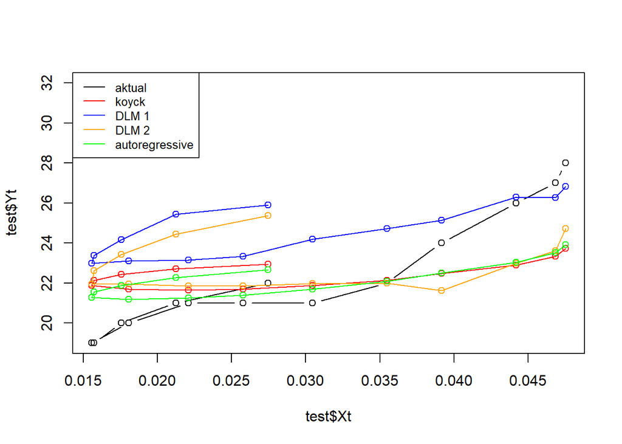

```r
par(mfrow=c(1,1))
plot(test$Xt, test$Yt, type="b", col="black", ylim=c(19,32))
points(test$Xt, fore.koyck$forecasts,col="red")
lines(test$Xt, fore.koyck$forecasts,col="red")
points(test$Xt, fore.dlm$forecasts,col="blue")
lines(test$Xt, fore.dlm$forecasts,col="blue")
points(test$Xt, fore.dlm2$forecasts,col="orange")
lines(test$Xt, fore.dlm2$forecasts,col="orange")
points(test$Xt, fore.ardl$forecasts,col="green")
lines(test$Xt, fore.ardl$forecasts,col="green")
legend("topleft",c("aktual", "koyck","DLM 1","DLM 2", "autoregressive"), lty=1, col=c("black","red","blue","orange","green"), cex=0.8)
```

Berdasarkan plot tersebut, terlihat bahwa plot yang paling mendekati data aktualnya adalah Model autoregressive, sehingga dapat disimpulkan model terbaik dalam hal ini adalah model regresi autoregressive.